# Task 3 - Santa Barbara Urchins

Conner Smith

10/22/2021

# **Overview**

The purpose of this task is to explore red and purple urchins recorded by Santa Barbara Coastal Long Term Ecological Research program divers. In this task, the size differences between these two primary species are explored and explained. The data is then parsed by observation reef where counts of purple urchins are taken over the period between 2008 and 2020 to identify any possible shifts in the urchin population across sites.

Data: Reed, D. 2020. SBC LTER: Reef: Long-term experiment: Kelp removal: Urchin size frequency distribution ver 20. Environmental Data Initiative. https://doi.org/10.6073/pasta/5a1e9ef03aa47bd2225c0bb98a02a63b.

# **Setup**

```r
knitr::opts_chunk$set(echo = TRUE, message = FALSE, warning = FALSE)
# Attach packages
library(tidyverse)
library(here)
library(janitor)
library(lubridate)
library(kableExtra)
```

# **Raw Data**

```r
# Read in the raw urchins datam using relative file paths

urchins <- read_csv(here("data", "urchins.csv"))
```

# **Section 1**

This section includes a visualization of the raw data after some initial steps were taken to clean up the data.

```r
# Convert all column names to lower snake case and standardize the date formatting

urchins_clean <- urchins %>%
  clean_names() %>%
  mutate(date = mdy(date))
```

#### **Figure 1**: Santa Barbara Sea Urchin Size by Species

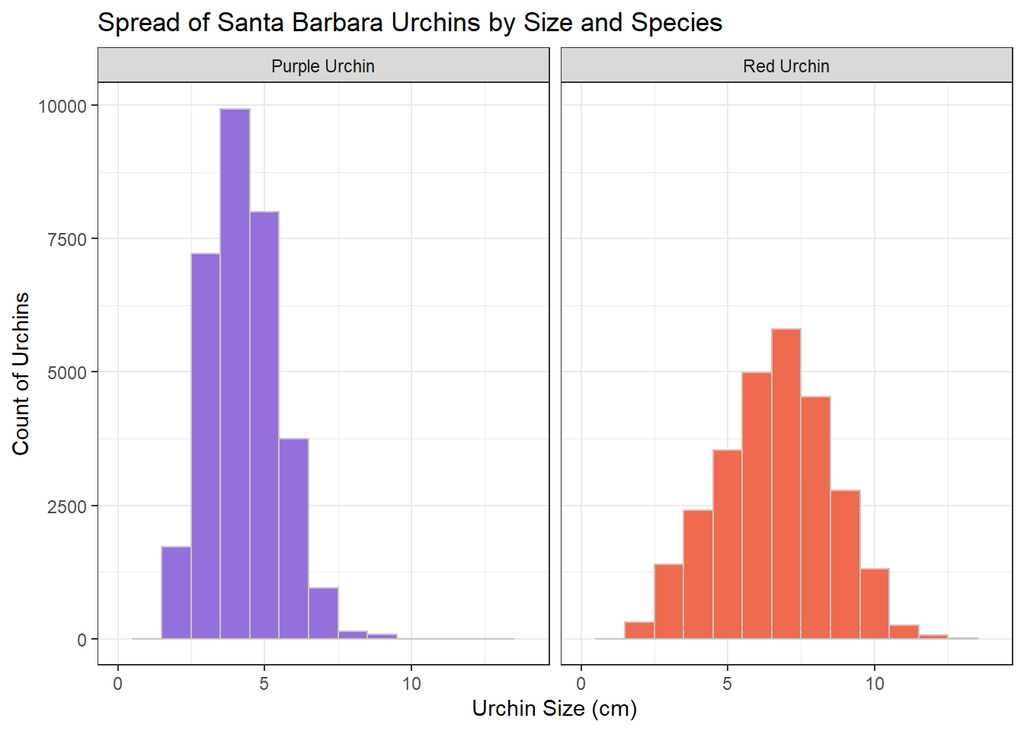

```r
# Visualize the urchin size with a faceted histogram. Change the number of bins, bin width, axis limits, and color options.

ggplot(data = urchins_clean, aes(x = size)) +
  geom_histogram(aes(fill = common_name), color = "seashell3",
                 bins = 10, binwidth = 1,
                 show.legend = FALSE) +
  scale_fill_manual(values = c("mediumpurple", "coral2")) +
  xlim(0, 14) +
  facet_wrap(~ common_name) +
  theme_bw() +
  labs(x = "Urchin Size (cm)", y = "Count of Urchins",
       title = "Spread of Santa Barbara Urchins by Size and Species")
```

**Figure 1: Santa Barbara Sea Urchin Size by Species.** *These data describe the size distribution of red and purple sea urchins at SBC LTER long-term kelp removal experiment sites. Sea urchin size was measured to the nearest 0.5 cm.*

The data visualized above are presented below in a summary table

#### **Table 1**: Santa Barbara Sea Urchin Size Stats by Species

**Table 1: Santa Barbara Sea Urchin Size Stats by Species.** *This table provides summary statistics for Santa Barbara urchins by species. Roughly 30,000 samples of each species were collected.*

```r
# Create a summary table of the mean, median, sample size, and standard deviation of the data after grouping by species.

urchins_stats <- urchins_clean %>%
  group_by(common_name) %>%
  summarize(sample_size = n(),
            mean_size = mean(size, na.rm = TRUE),
            median_size = median(size),
            sd_size = sd(size))


urchins_stats %>%
  kable(col.names = c("Species",
                      "Sample Size",
                      "Mean Size (cm)",
                      "Median Size (cm)",
                      "Standard Deviation (cm)"), digits = 2) %>%
  kable_styling(full_width = FALSE)
```

| Species | Sample Size | Mean Size (cm) | Median Size (cm) | Standard Deviation (cm) |
| --- | --- | --- | --- | --- |
| Purple Urchin | 31805 | 4.47 | 4.5 | 1.18 |
| Red Urchin | 27408 | 6.78 | 7.0 | 1.89 |

This summary shows that on average, the diameter of purple urchins is roughly 2.3 centimeters (or 34 percent) smaller than that of red urchins in Santa Barbara. The central tendency for the purple urchins and red urchins tends to 4.5 centimeters and 7 centimeters, respectively. There is greater spread in the size distribution of the red urchins sampled with a standard deviation of 1.9. The spread of purple urchin size is clustered more closely around the mean size of 4.5 centimeters.

# **Section 2**

This section includes some data reformatting and a graph

```r
# Filter the data to show only purple urchins and create new columns for year and full site names

purple_urchins <- urchins_clean %>%
  filter(common_name == "Purple Urchin") %>%
  rename(date_new = date) %>%
  mutate(date_new = as.Date(date_new)) %>%
  mutate(year = year(date_new)) %>%
  mutate(name_full = case_when(site == "AQUE" ~ "Arroyo Quemado Reef",
                               site == "CARP" ~ "Carpinteria Reef",
                               site == "IVEE" ~ "Isla Vista Reef",
                               site == "MOHK" ~ "Mohawk Reef",
                               site == "NAPL" ~ "Naples Reef"))
```

The following graph draws from a data frame summarizing the filtered data.

```r
# Make a new data frame with the filtered data set showing total number of urchins by site and year. Do not show in the knitted document.

purple_urchins_summary <- purple_urchins %>%
  group_by(name_full, year) %>%
  summarize(urchin_count = n())
```

#### **Figure 2**: Purple Sea Urchin Count By Station (2008-2020)

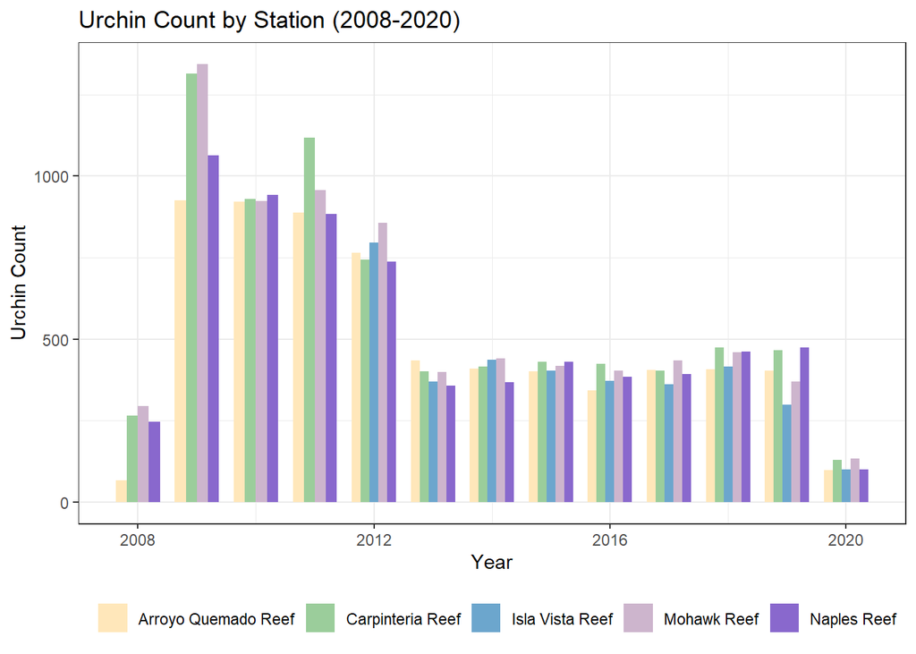

```r
ggplot(data = purple_urchins_summary, aes(x = year, y = urchin_count)) +
  geom_col(aes(fill = name_full),
           width = 0.75,
           position = "dodge",
           show.legend = TRUE) +
  scale_fill_manual(values = c("wheat1","darkseagreen3", "skyblue3",
                               "thistle3", "mediumpurple3")) +
  theme_bw() +
  theme(legend.position = "bottom") +
  theme(legend.title = element_blank())+
  labs(x = "Year", y = "Urchin Count",
       title = "Urchin Count by Station (2008-2020)")
```

**Figure 2: Purple Sea Urchin Count By Station (2008-2020).** *These data describe the count of purple sea urchins across the five study stations between 2008 and 2020.*

Without considering additional factors, this graph appears to show a decline in the number of urchins observed across the sites over this time period. In each of the sites besides Isla Vista Reef where observation only began in 2012, urchin observations peaked between 2008 and 2012. To determine if these changes reflect actual changes in the population, one would have to be sure that the sample is an accurate representation. For example, it is possible that only the urchins in these locations were declining while they were increasing elsewhere. To get a better sense of how representative this sample is, researchers could calculate a confidence interval on various characteristics of the urchins. It would also be helpful to identify any additional variables like shifting environmental conditions at specific locations or study design differences that could help justify the theory that urchin populations are declining in Santa Barbara. Otherwise, these declines may not be reflective of population shifts.

## End Task 3